# Overview of recent and advanced features in NIMBLE

# Automatic parameter transformations

Many algorithms work better in unconstrained parameter spaces.

Example: If `sigma ~ dunif(0, 20)`, then any MCMC or optimization algorithm will have issues exploring outside the constraint [0, 20].

The built-in `nimbleFunction` called `parameterTransform` provides a generic way to map from constrained to unconstrained parameter spaces and back.

This is used for example by the NUTS (HMC) sampler and Laplace approximation. You can use it in new algorithms that you write.

# Bayesian non-parametric (BNP) distributions

Random effects (and residuals) are very often assumed to be normally distributed without checking or alternatives.

Non-parametric distributions are “arbitrary”, or at least very flexible.

Mixtures of normal distributions can be used for this purpose.

Here are two examples:

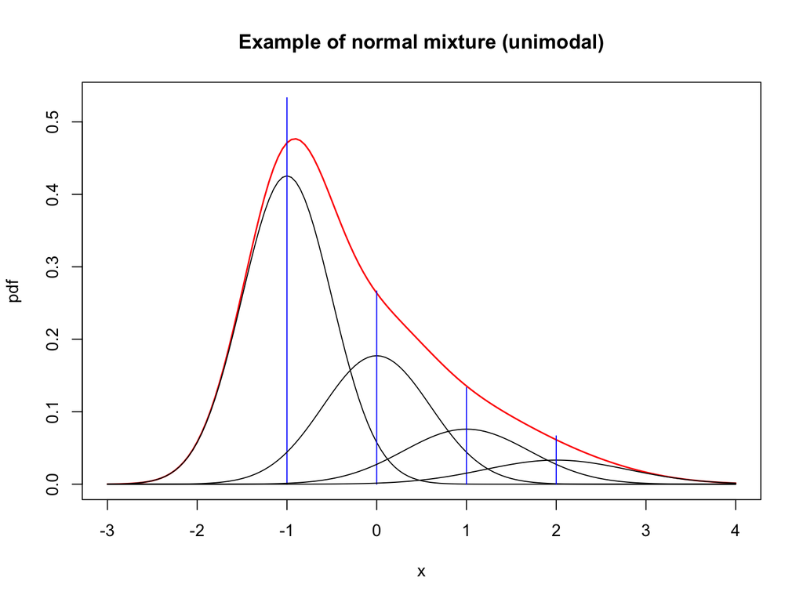

```r
weights <- c(1, .5, .25, .125)
weights <- weights / sum(weights)
centers <- c(-1, 0, 1, 2)
sds <- c(0.5, 0.6, 0.7, 0.8)
x <- seq(-3, 4, by = 0.05)
pdf <- x |> lapply(\(x) sum(weights * dnorm(x, centers, sds))) |> unlist()
{
  plot(x, pdf, type ='l', col = "red", lwd = 1.5,
       main = "Example of normal mixture (unimodal)",
       ylim = c(0, max(c(weights, pdf))))
  for(i in seq_along(weights)) {
    points(x, weights[i] * dnorm(x, centers[i], sds[i]), type = 'l' )
    points(c(centers[i], centers[i]), c(0, weights[i]), type = 'l', col = 'blue')
  }
}
```

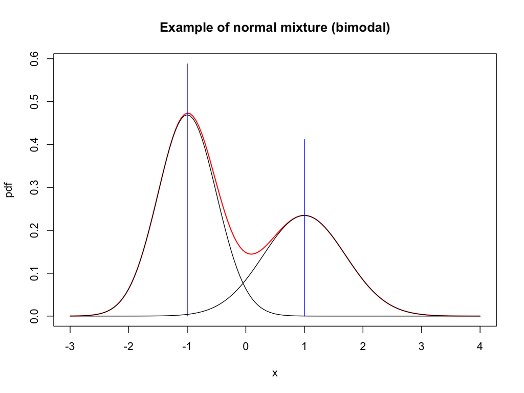

```r
weights <- c(1, .7)
weights <- weights / sum(weights)
centers <- c(-1, 1)
sds <- c(0.5, 0.7)
x <- seq(-3, 4, by = 0.05)
pdf <- x |> lapply(\(x) sum(weights * dnorm(x, centers, sds))) |> unlist()
{
  plot(x, pdf, type ='l', col = "red", lwd = 1.5,
       main = "Example of normal mixture (bimodal)",
       ylim = c(0, max(c(weights, pdf))))
  for(i in seq_along(weights)) {
    points(x, weights[i] * dnorm(x, centers[i], sds[i]), type = 'l' )
    points(c(centers[i], centers[i]), c(0, weights[i]), type = 'l', col = 'blue')
  }
}
```

We want to estimate these.

See for example [Turek, Wehrhahn and Gimenez (2021). Bayesian non-parametric detection heterogeneity in ecological models.](https://link.springer.com/article/10.1007/s10651-021-00489-1)

# Simulate from a mixture of normals

Let’s use the second example above. We’ll first simulate group identities and then normal draws given group identities.

```r
set.seed(1)
n <- 500
weights <- c(1, .7) # same as above...
weights <- weights / sum(weights)
centers <- c(-1, 1)
sds <- c(0.5, 0.7) #... to here
ID <- sample(1:2, prob = weights, size = n, replace = TRUE)
head(ID)
```

```
## [1] 1 1 1 2 1 2
```

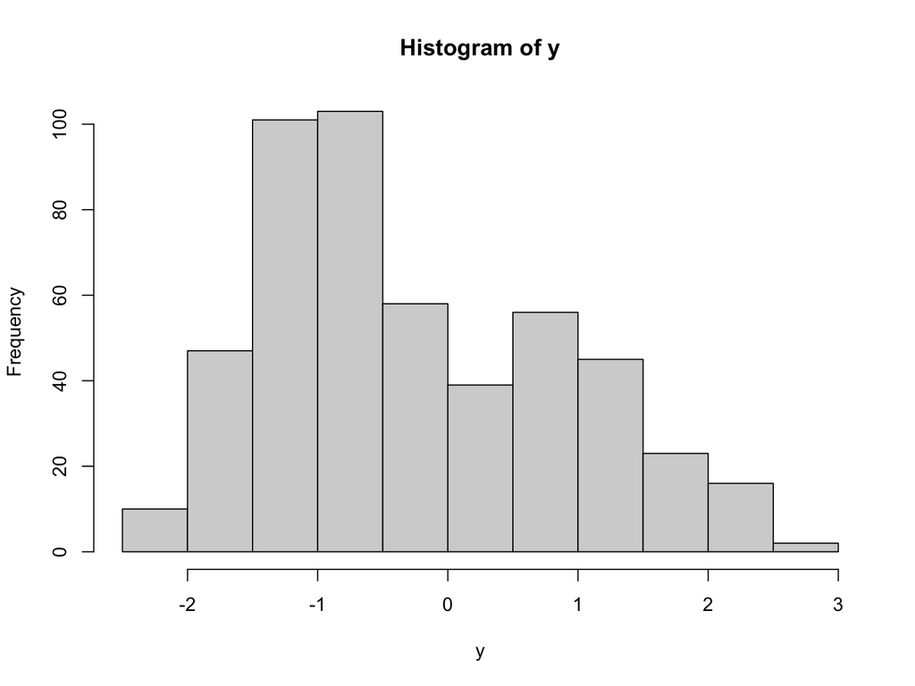

```r
y <- rnorm(n, centers[ID], sds[ID])
hist(y)
```

# Bayesian estimation of non-parametric distributions

Methods are often related to a “Dirichlet process” (DP) (not the same as a Dirichlet distribution).

### Chinese restaurant process

The DP has at its core a model for clustering, which is usually called a Chinese restaurant process (CRP).

(There is also a “stick-breaking” representation that we won’t show.)

Here’s the idea - we represent the probability of a new customer sitting at each table as follows:

Under the CRP, the probability that the i’th customer sits at an unoccupied table is:

$$\frac{\alpha}{i-1+\alpha}$$

and the probability the customer sits at table $k$ (where there are $n_k$ people already at the table) is:

$$\frac{n_k}{i-1+\alpha}$$

- Each table represents a normal distribution in the mixture.
- The number of customers is related to the weight for that mixture component. (The weight is not written explicitly.)
- There is a mean and standard deviation for each mixture component.

# Fitting a CRP model

This model code comes from the nimble User Manual (section 10.2).

```r
code <- nimbleCode({
  z[1:N] ~ dCRP(alpha, size = N)
  alpha ~ dgamma(1, 1)
  for(i in 1:M) {
    thetatilde[i] ~ dnorm(0, var = 100)
    s2tilde[i] ~ dinvgamma(1, 1)
  }
  for(i in 1:N)
    y[i] ~ dnorm(thetatilde[z[i]], var = s2tilde[z[i]])
})

constants <- list(N = 500, M = 10)
data <- list(y = y)
inits <- list(thetatilde = rnorm(constants$M, 0, 10),
              s2tilde = rinvgamma(constants$M, 1, 1),
              z = sample(1:4, size = constants$N, replace = TRUE),
              alpha  = 1)
model <- nimbleModel(code, constants, data, inits)
```

```
## Defining model
```

```
## Building model
```

```
## Setting data and initial values
```

```
## Running calculate on model
##   [Note] Any error reports that follow may simply reflect missing values in model variables.
```

```
## Checking model sizes and dimensions
```

# Fitting a CRP model (cont)

We must be sure to monitor (record) `z`.

```r
mcmcConf <- configureMCMC(model)
```

```
## ===== Monitors =====
## thin = 1: alpha, s2tilde, thetatilde
## ===== Samplers =====
## CRP_concentration sampler (1)
##   - alpha
## CRP_cluster_wrapper sampler (20)
##   - s2tilde[]  (10 elements)
##   - thetatilde[]  (10 elements)
## CRP sampler (1)
##   - z[1:500]
```

```r
mcmcConf$addMonitors('z') # We must be sure to monitor (record) z
```

```
## thin = 1: alpha, s2tilde, thetatilde, z
```

```r
mcmc <- buildMCMC(mcmcConf)
```

```
##   [Warning] sampler_CRP: The number of clusters based on the cluster parameters
##             is less than the number of potential clusters. The MCMC is not
##             strictly valid if it ever proposes more components than cluster
##             parameters exist; NIMBLE will warn you if this occurs.
```

```r
comp <- compileNimble(model, mcmc)
```

```
## Compiling
##   [Note] This may take a minute.
##   [Note] Use 'showCompilerOutput = TRUE' to see C++ compilation details.
```

```r
samples <- runMCMC(comp$mcmc, nchains = 1, niter = 10000)
```

```
## running chain 1...
```

```
## |-------------|-------------|-------------|-------------|
## |-------------------------------------------------------|
```

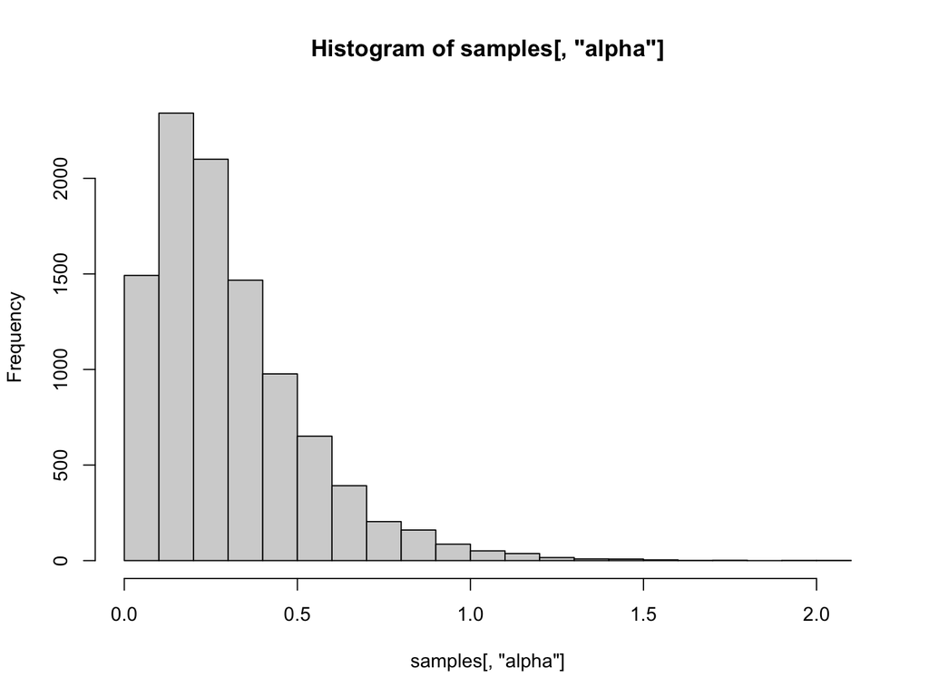

```r
hist(samples[,'alpha'])
```

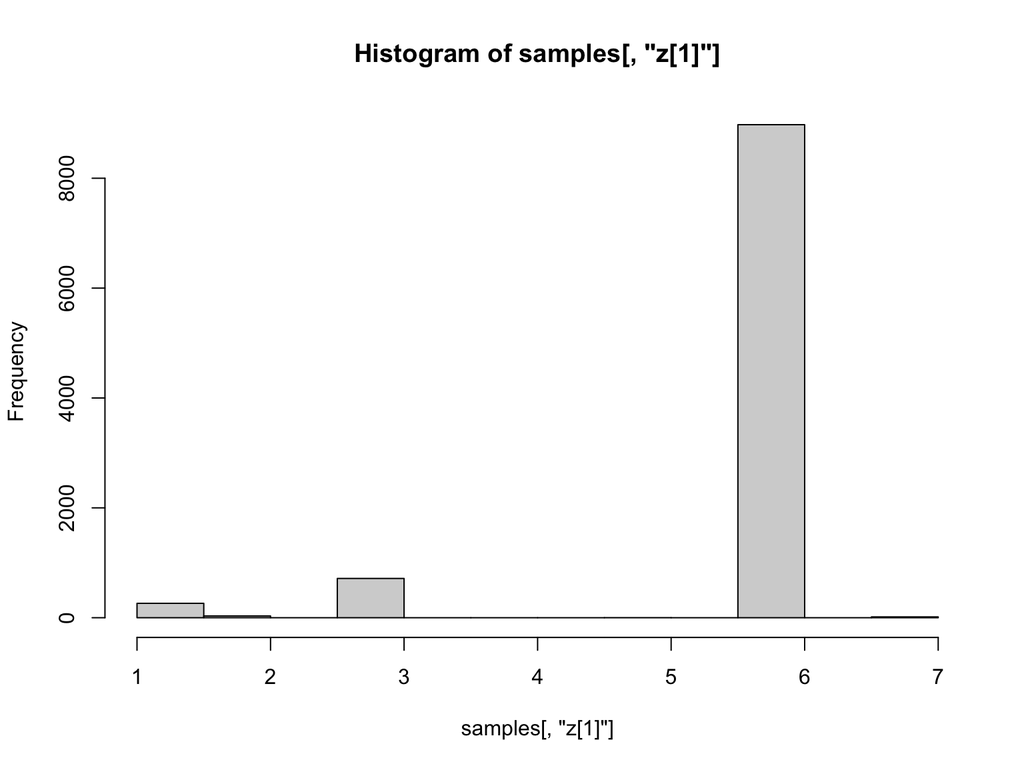

```r
hist(samples[,'z[1]'])
```

It can be difficult to see the BNP distribution itself. There is a tool for that: (It will use `compileNimble` and take a minute.)

```r
DPsamples <- getSamplesDPmeasure(comp$mcmc)
```

```
## Compiling
##   [Note] This may take a minute.
##   [Note] Use 'showCompilerOutput = TRUE' to see C++ compilation details.
```

```
## |-------------|-------------|-------------|-------------|
## |-------------------------------------------------------|
```

`DPsamples` is a *list* matrices, one for each row of the MCMC samples. Let’s look at a few.

```r
DPsamples[[500]]
```

```
##           weights s2tilde[1] thetatilde[1]
## [1,] 0.3933341314  0.6324081     0.7822082
## [2,] 0.0361147292  2.7536270    -0.1875131
## [3,] 0.5704960775  0.1853141    -1.0473973
## [4,] 0.0000550619  1.8872932     3.1114889
```

```r
DPsamples[[600]]
```

```
##           weights s2tilde[1] thetatilde[1]
## [1,] 3.865797e-01  0.5256496     1.0095619
## [2,] 6.111196e-01  0.2784223    -0.9926974
## [3,] 2.034335e-03  2.5588117   -15.5529188
## [4,] 2.230952e-04  0.2374532    -6.4268288
## [5,] 4.057781e-05  0.5623782     2.0235376
## [6,] 2.399109e-07 16.2991648   -13.3951112
## [7,] 1.414518e-07  1.7542509    -5.7293013
## [8,] 2.355397e-06  1.7593171     1.5166372
```

```r
DPsamples[[700]]
```

```
##           weights s2tilde[1] thetatilde[1]
## [1,] 0.3918094557  0.4573572     0.8774947
## [2,] 0.6075622793  0.2573893    -0.9507213
## [3,] 0.0003687209  2.3683339     6.9051786
## [4,] 0.0002595442  0.8037108     3.9570646
```

We can see the results look reasonable and will stop there.

# Bayesian variable selection

- You have many candidate explanatory variables.
- Bayesian approach is to have a probability that a variable is included in the model.
- Really this is a probability that the coefficient is $\ne 0$.
- Common implementation is with indicator variables.
- This has problems. Let’s look at it.

# Set up a model

Use linear regression for simplicity.

- 5 “real” effects (true coefficient $\ne 0$)
- 10 null effects (true coefficient $= 0$).

### Create `nimble` model

```r
library(nimble)
lmCode <- nimbleCode({
  psi ~ dunif(0,1)   # prior on inclusion probability
  sigma ~ dunif(0, 20)
  for(i in 1:numVars) {
    z[i] ~ dbern(psi) # indicator variable
    beta[i] ~ dnorm(0, sd = 100)
    zbeta[i] <- z[i] * beta[i]  # indicator * beta
  }
  for(i in 1:n) {
    pred.y[i] <- inprod(X[i, 1:numVars], zbeta[1:numVars])
    y[i] ~ dnorm(pred.y[i], sd = sigma)
  }
})
set.seed(1)
X <- matrix(rnorm(100*15), nrow = 100, ncol = 15)
lmConstants <- list(numVars = 15, n = 100, X = X)
lmModel <- nimbleModel(lmCode, constants = lmConstants)
```

```
## Defining model
```

```
## Building model
```

```
## Setting data and initial values
```

```
## Running calculate on model
##   [Note] Any error reports that follow may simply reflect missing values in model variables.
```

```
## Checking model sizes and dimensions
```

```
##   [Note] This model is not fully initialized. This is not an error.
##          To see which variables are not initialized, use model$initializeInfo().
##          For more information on model initialization, see help(modelInitialization).
```

### Simulate data using `nimble` model.

```r
true_betas <- c(c(0.1, 0.2, 0.3, 0.4, 0.5),
                rep(0, 10))
lmModel$beta <- true_betas
lmModel$sigma <- 1
lmModel$z <- rep(1, 15)
lmModel$psi <- 0.5
lmModel$calculate()
```

```
## [1] NA
```

```r
set.seed(0) ## Make this reproducible
lmModel$simulate('y')
lmModel$y
```

```
##   [1]  2.093746080  0.736124260  2.027064905  1.015404063  0.084651727
##   [6] -0.102184583 -0.686491964  0.202594710  0.435718990  2.644015748
##  [11]  0.961672768 -0.360245858 -0.662667183 -1.700501339 -0.200258772
##  [16]  0.650832608  0.409270819 -1.403333432 -0.423337248 -0.174741477
##  [21]  0.487168232  0.968487430  0.202134183 -1.160597424  0.115539231
##  [26]  2.170098572 -0.003863118 -1.648798404 -2.075791272  0.033745581
##  [31] -1.531037727 -1.914773221 -1.393267801 -0.254103524  0.795219196
##  [36]  0.967671016  1.885420816 -0.908136075  1.082161648 -0.104709767
##  [41]  1.649691365  1.541881532 -0.559683516 -0.822087590 -1.913115062
##  [46] -3.954117862 -1.589976002  0.871605491  0.953431209 -0.577571628
##  [51]  1.507252727 -0.350772513  2.166512914 -2.023372326 -0.096192075
##  [56]  0.843670922 -0.154148031 -1.340666932 -3.601141277 -0.841059715
##  [61] -0.294235021  1.428815064 -0.376621679  0.447239839 -0.562541558
##  [66]  1.167947335 -1.864871858  0.412053056  0.646638107  0.038506671
##  [71] -0.111487777 -0.372454814 -1.136155107  0.759649263  0.727207754
##  [76]  0.799602352 -0.196032522  0.578105952 -0.562616047 -0.287549737
##  [81] -0.854396858  1.186251149  0.703220412 -0.991016964  1.201811830
##  [86]  0.482899480  0.260664826 -0.559752750 -0.411360653  0.722577891
##  [91]  1.076918845  0.829422515  0.045169860 -0.894457768  2.907929426
##  [96] -0.917876409  0.899026957  0.946590373  0.061559025  0.690701001
```

```r
lmModel$calculate()
```

```
## [1] -226.7382
```

```r
lmModel$setData('y')
lmData = list(y = lmModel$y)
```

# Look at `lm`

It will be helpful to refer to back simple linear regression:

```r
summary(lm(lmModel$y ~ lmModel$X))
```

```
##
## Call:
## lm(formula = lmModel$y ~ lmModel$X)
##
## Residuals:
##      Min       1Q   Median       3Q      Max
## -2.32512 -0.49673 -0.00609  0.56855  2.17110
##
## Coefficients:
##              Estimate Std. Error t value Pr(>|t|)
## (Intercept) -0.001390   0.098714  -0.014 0.988795
## lmModel$X1   0.177426   0.103873   1.708 0.091310 .
## lmModel$X2   0.123335   0.098356   1.254 0.213334
## lmModel$X3   0.356547   0.092810   3.842 0.000236 ***
## lmModel$X4   0.450670   0.097557   4.620 1.37e-05 ***
## lmModel$X5   0.414989   0.080192   5.175 1.53e-06 ***
## lmModel$X6  -0.108063   0.097754  -1.105 0.272117
## lmModel$X7   0.109590   0.086844   1.262 0.210470
## lmModel$X8  -0.064770   0.087194  -0.743 0.459658
## lmModel$X9   0.005129   0.091048   0.056 0.955214
## lmModel$X10 -0.065272   0.096850  -0.674 0.502191
## lmModel$X11  0.012760   0.090297   0.141 0.887959
## lmModel$X12  0.182145   0.092908   1.960 0.053254 .
## lmModel$X13  0.116821   0.090177   1.295 0.198706
## lmModel$X14 -0.118522   0.110125  -1.076 0.284899
## lmModel$X15  0.017310   0.096353   0.180 0.857861
## ---
## Signif. codes:  0 '***' 0.001 '**' 0.01 '*' 0.05 '.' 0.1 ' ' 1
##
## Residual standard error: 0.8874 on 84 degrees of freedom
## Multiple R-squared:  0.5416, Adjusted R-squared:  0.4597
## F-statistic: 6.616 on 15 and 84 DF,  p-value: 4.146e-09
```

# Look at nimble results with default samplers.

```r
MCMCconf <- configureMCMC(lmModel)
```

```
## ===== Monitors =====
## thin = 1: beta, psi, sigma
## ===== Samplers =====
## RW sampler (2)
##   - psi
##   - sigma
## conjugate sampler (15)
##   - beta[]  (15 elements)
## binary sampler (15)
##   - z[]  (15 elements)
```

```r
MCMCconf$addMonitors('z')
```

```
## thin = 1: beta, psi, sigma, z
```

```r
MCMC <- buildMCMC(MCMCconf)
ClmModel <- compileNimble(lmModel)
```

```
## Compiling
##   [Note] This may take a minute.
##   [Note] Use 'showCompilerOutput = TRUE' to see C++ compilation details.
```

```r
CMCMC <- compileNimble(MCMC, project = lmModel, resetFunctions = TRUE)
```

```
## Compiling
##   [Note] This may take a minute.
##   [Note] Use 'showCompilerOutput = TRUE' to see C++ compilation details.
```

```r
set.seed(100)
system.time(samples_nimble <- runMCMC(CMCMC, niter = 100000, nburnin = 10000))
```

```
## running chain 1...
```

```
## |-------------|-------------|-------------|-------------|
## |-------------------------------------------------------|
```

```
##    user  system elapsed
##  37.528   0.063  37.638
```

# Look at default nimble results

### Look at beta[1]

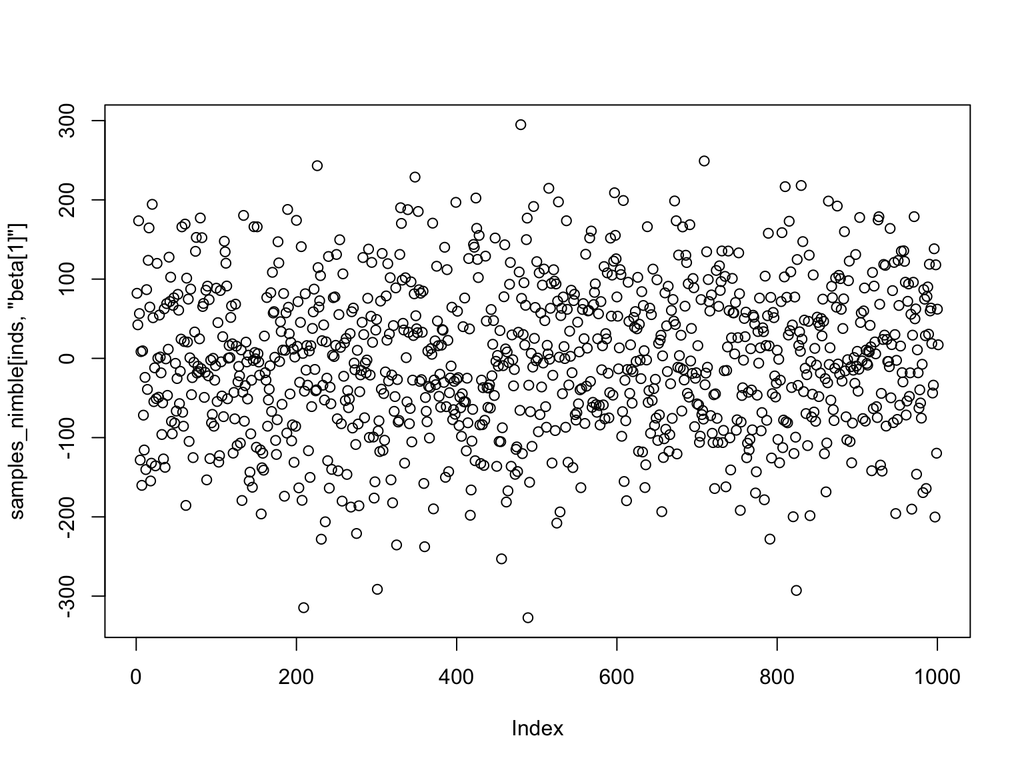

```r
inds <- seq(50000, 60000, by=10) ## Look at arbitrary 1001 iterations thinned
plot(samples_nimble[inds,'beta[1]'])
```

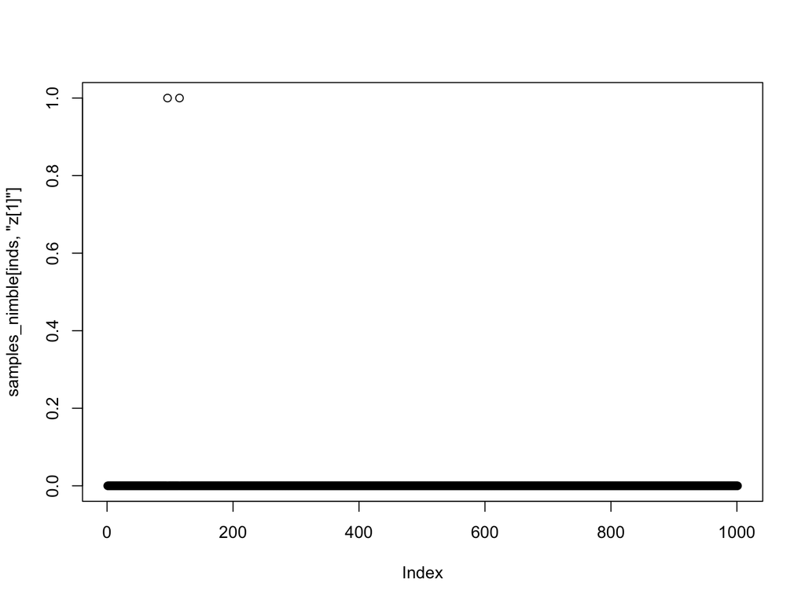

```r
plot(samples_nimble[inds,'z[1]'])
```

### Look at beta[4]

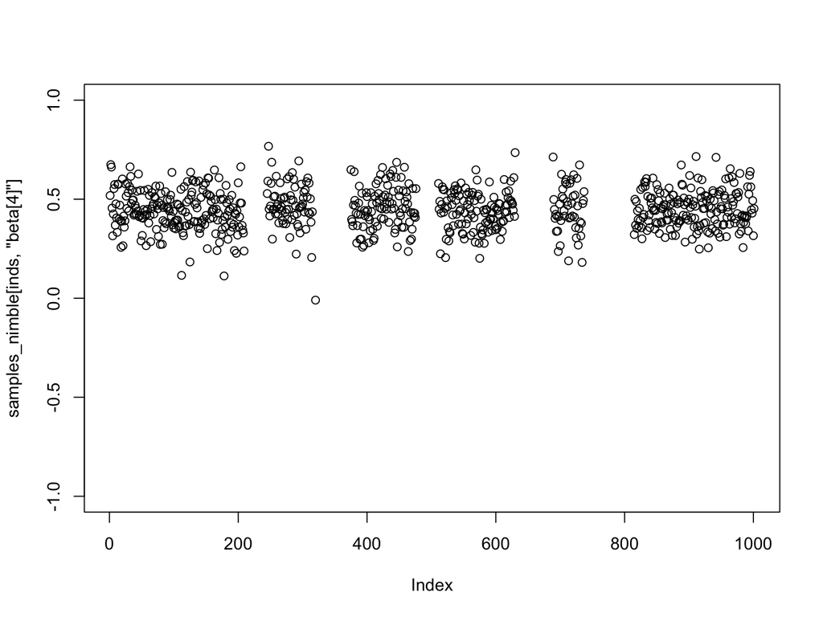

```r
plot(samples_nimble[inds,'beta[4]'], ylim = c(-1, 1))
```

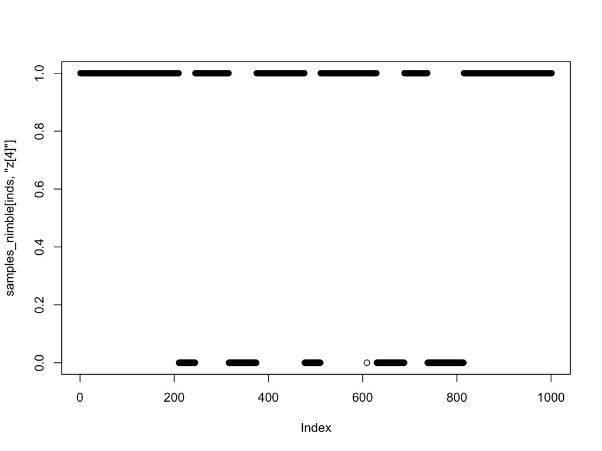

```r
plot(samples_nimble[inds,'z[4]'])
```

### Look at beta[5]

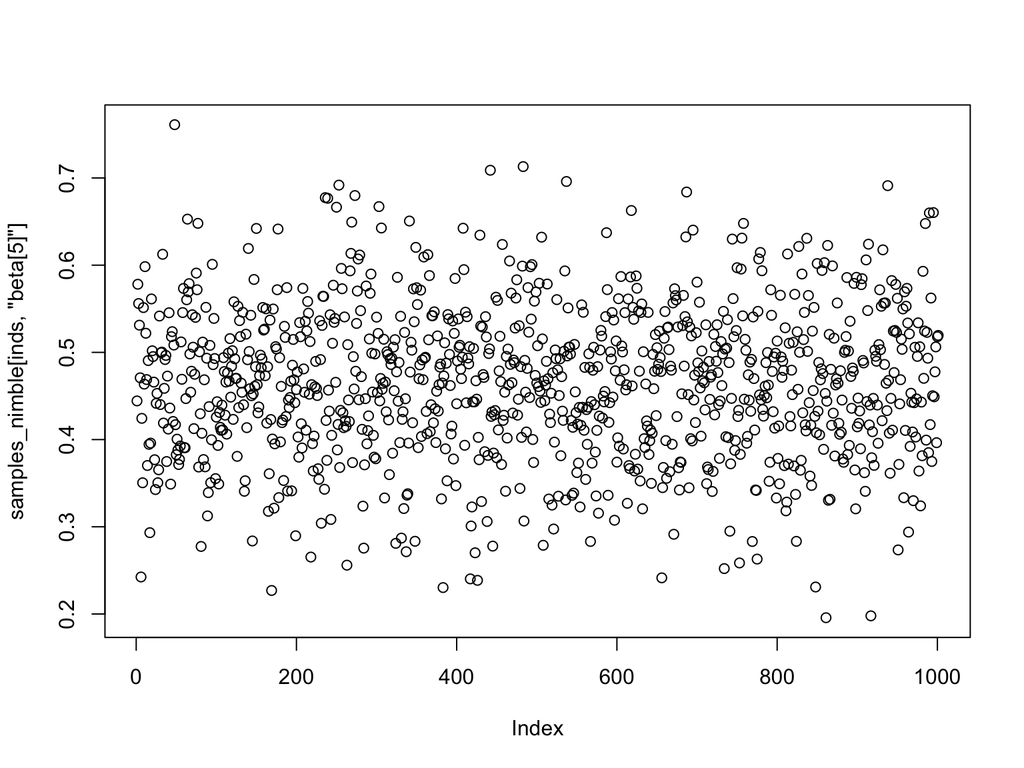

```r
plot(samples_nimble[inds,'beta[5]'])
```

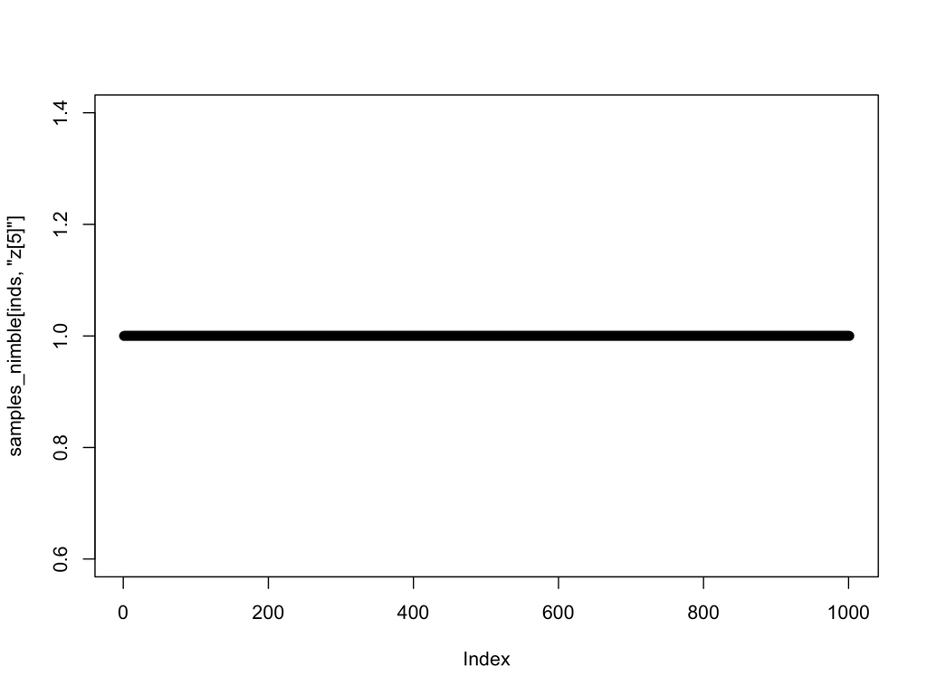

```r
plot(samples_nimble[inds,'z[5]'])
```

### Look at posterior inclusion probabilities from each `beta[i]`

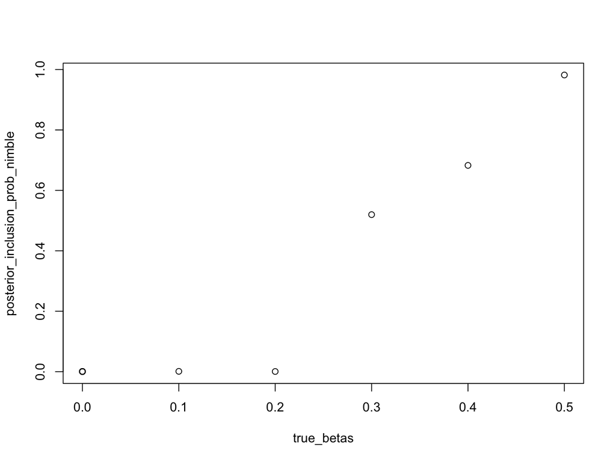

```r
zCols <- grep("z\\[", colnames(samples_nimble))
posterior_inclusion_prob_nimble <- colMeans(samples_nimble[,zCols])
plot(true_betas, posterior_inclusion_prob_nimble)
```

### Look at posterior inclusion probability, `psi`

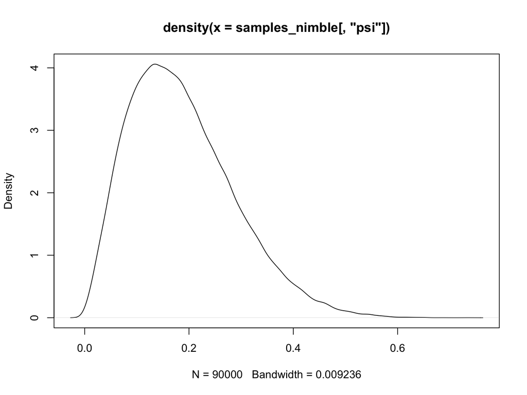

```r
plot(density(samples_nimble[,'psi']))
```

# Summary of results from default nimble

- `beta[3]`, `beta[4]` and `beta[5]` are often included.
- When `z[i] = 0`, the corresponding `beta[i]` will start following its **prior**. It may wander far away from reasonable values, with either fast or slow mixing (depending on the situation).
- Different samplers (e.g. slice samplers for `beta[i]`s) could do better but not solve the fundamental problem.

# Summary of Mixing problems (the main issue)

### Wasteful computation (a secondary issue)

- When `z[i] = 0`, we’d like to not be wasting computation on `beta[i]`.

# Solution: Reversible Jump MCMC

- RJMCMC is a method for sampling across different models.
- Specifically it is about sampling between different numbers of dimensions.
- We don’t change the actual nimble model object, but we turn on and off which dimensions are sampled.
- Implementation, like all samplers, is written using `nimbleFunction`s.

# RJMCMC for variable selection in nimble

- Update an MCMC configuration to use RJMCMC.

```r
# make a new copy of the model to be totally independent
lmModel2 <- lmModel$newModel(replicate = TRUE)
```

```
## Checking model sizes and dimensions
```

```
##   [Note] This model is not fully initialized. This is not an error.
##          To see which variables are not initialized, use model$initializeInfo().
##          For more information on model initialization, see help(modelInitialization).
```

```r
MCMCconfRJ <- configureMCMC(lmModel2)
```

```
## ===== Monitors =====
## thin = 1: beta, psi, sigma
## ===== Samplers =====
## RW sampler (2)
##   - psi
##   - sigma
## conjugate sampler (15)
##   - beta[]  (15 elements)
## binary sampler (15)
##   - z[]  (15 elements)
```

```r
MCMCconfRJ$addMonitors('z')
```

```
## thin = 1: beta, psi, sigma, z
```

```r
configureRJ(MCMCconfRJ,
            targetNodes = 'beta',
            indicatorNodes = 'z',
            control = list(mean = 0, scale = .2))
MCMCRJ <- buildMCMC(MCMCconfRJ)
```

# Run the RJMCMC

```r
ClmModel2 <- compileNimble(lmModel2)
```

```
## Compiling
##   [Note] This may take a minute.
##   [Note] Use 'showCompilerOutput = TRUE' to see C++ compilation details.
```

```r
CMCMCRJ <- compileNimble(MCMCRJ, project = lmModel2)
```

```
## Compiling
##   [Note] This may take a minute.
##   [Note] Use 'showCompilerOutput = TRUE' to see C++ compilation details.
```

```r
set.seed(100)
system.time(samples_nimble_RJ <- runMCMC(CMCMCRJ, niter = 100000, nburnin = 10000))
```

```
## running chain 1...
```

```
## |-------------|-------------|-------------|-------------|
## |-------------------------------------------------------|
```

```
##    user  system elapsed
##  12.691   0.027  12.728
```

# Look at RJMCMC results

### Look at beta[1]

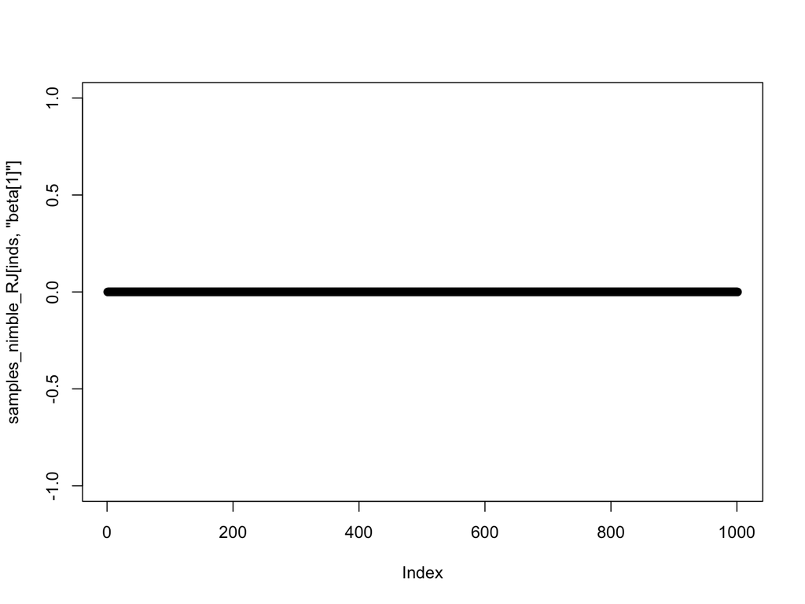

```r
inds <- seq(50000, 60000, by = 10)
plot(samples_nimble_RJ[inds,'beta[1]'])
```

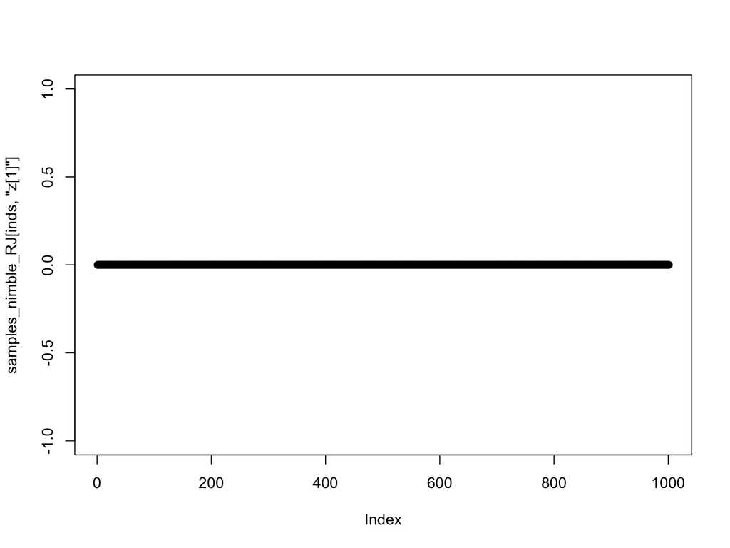

```r
plot(samples_nimble_RJ[inds,'z[1]'])
```

### Look at beta[4]

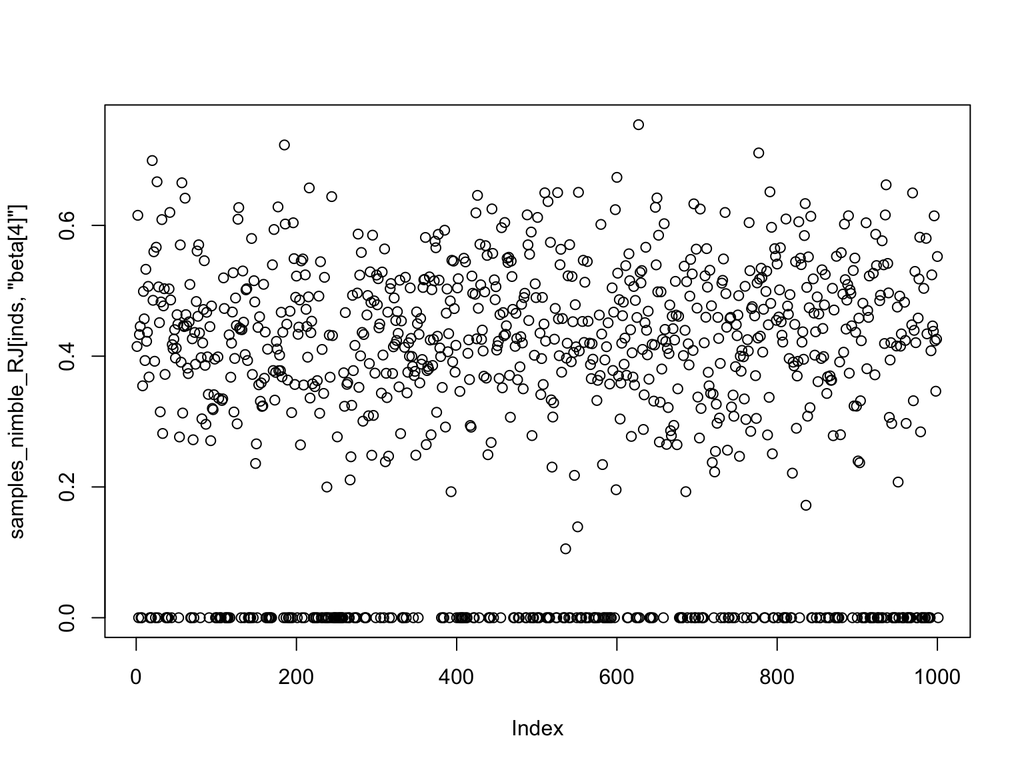

```r
plot(samples_nimble_RJ[inds,'beta[4]'])
```

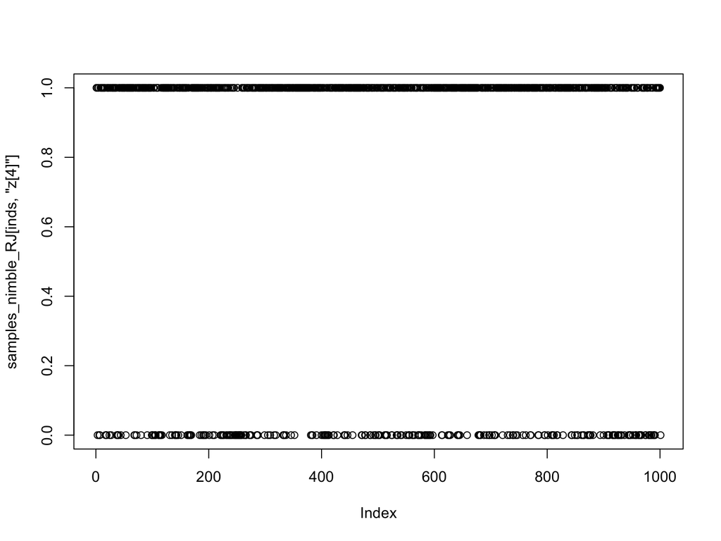

```r
plot(samples_nimble_RJ[inds,'z[4]'])
```

### Look at beta[5]

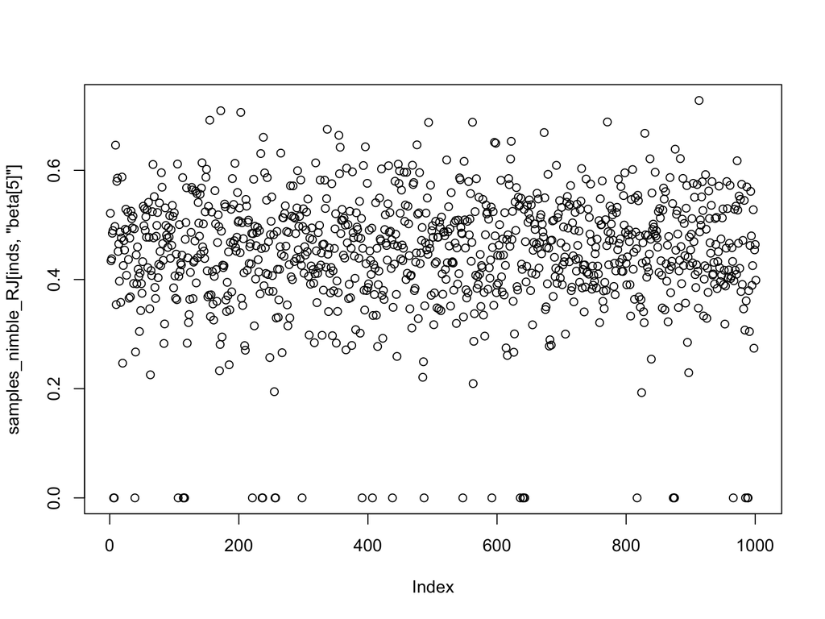

```r
plot(samples_nimble_RJ[inds,'beta[5]'])
```

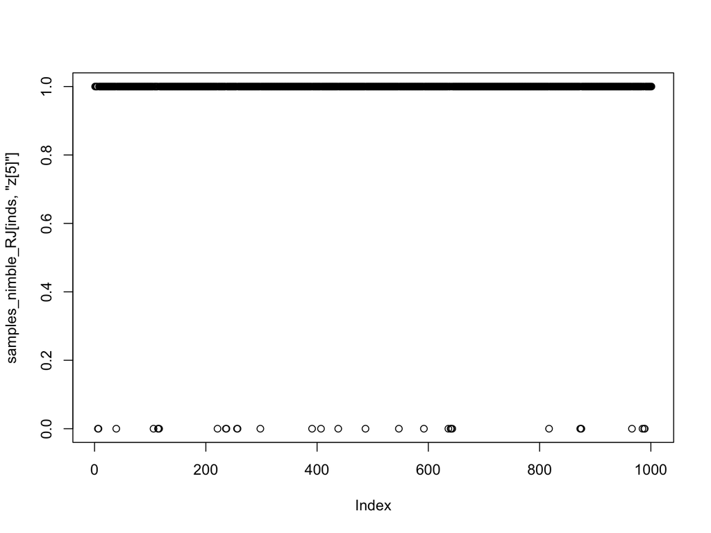

```r
plot(samples_nimble_RJ[inds,'z[5]'])
```

### Look at posterior inclusion probabilities of each `beta[i]`

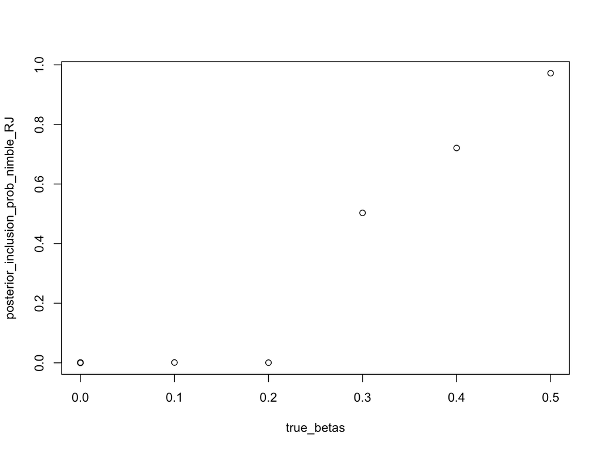

```r
zCols <- grep("z\\[", colnames(samples_nimble_RJ))
posterior_inclusion_prob_nimble_RJ <- colMeans(samples_nimble_RJ[,zCols])
plot(true_betas, posterior_inclusion_prob_nimble_RJ)
```

### Look at posterior inclusion probability, `psi`

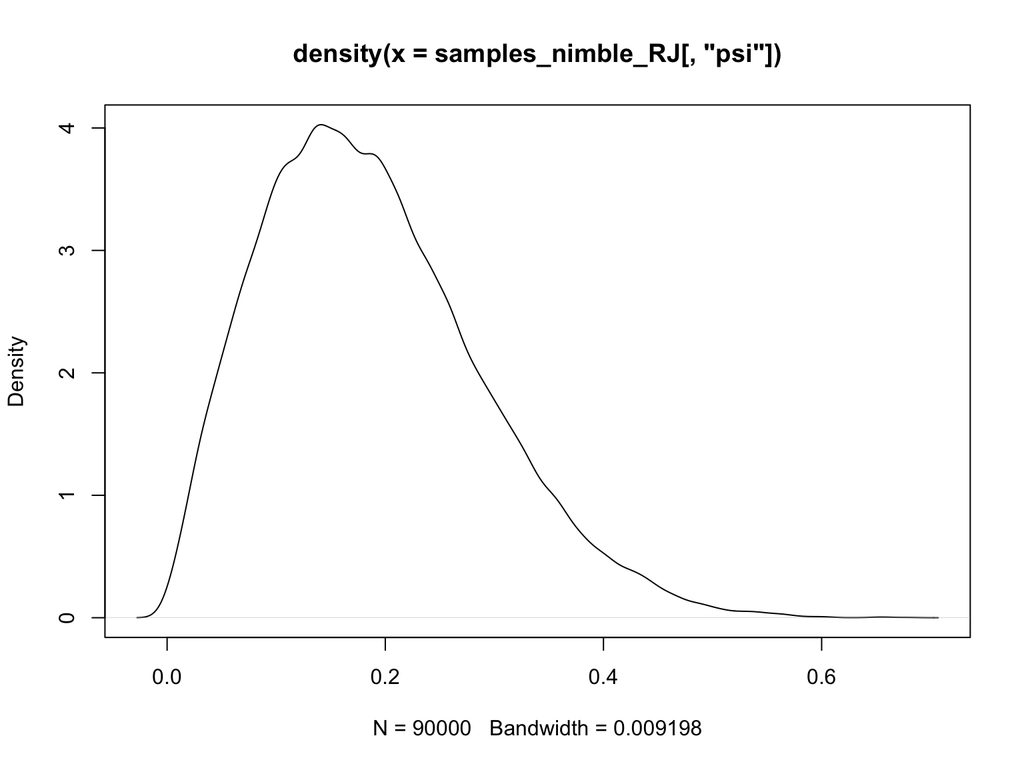

```r
plot(density(samples_nimble_RJ[,'psi']))
```

# Summary of RJMCMC

# Spatial capture-recapture

These models get big and inefficient for several reasons:

- All individuals might be detected anywhere (in theory).
- Imputed individuals (data augmentation) are computationally costly even when “not in the model”.
- Data structures can be very large and mostly 0s (individuals-x-detectors).
- Sampling can be inefficient.

[`nimbleSCR`](https://CRAN.R-project.org/package=nimbleSCR) provides tools to alleviate these problems. See its vignettes.

# Longer-term: better nimble workflows

Some things about `nimble` that are not so wonderful:

- You need to rebuild and recompile things in every R session.
- Objects can’t easily be saved and re-loaded.
- It is too hard to write packages using `nimble` internally.
- `nimble` can use a lot of memory.

We are working on improving these with deep rewriting of much of nimble’s core code. This will take time.